# CENP-B box screen across the DToL satellite repertoire

Generated 2026-08-14 · module `06_cenpb_box`

**Terminology.** A CENP-B **box** is a *functional* motif that binds the CENP-B protein. Here we detect *sequence* matches only, so we call them **motifs** / **candidate boxes**; none is a confirmed functional box (protein binding not tested).  
**Bottom line.** The canonical CENP-B motif (`[CT]TTCGTTGGAA[AG]CGGGA`) as an exact match is confined to human α-satellite — **0 exact canonical motifs in any of the 162 DToL species with satellites**. A ±5-flank test flags **box-like** motifs in 20 species, strongest in **birds**: the goshawk consensus `CTTTTTTGGAAACGGGA` is **15/17 identical** to the canonical box, differing only at the CpG (positions 4–5, CpG→TT). These are strong **candidate divergent boxes** — near-canonical but lacking the CENP-B-essential CpG (the exact broad motif, which fixes that CpG, therefore scores 0). Their functionality is untested (no protein-binding assay).

## What was searched

input`all.satellites.txt` — every **putative centromeric satellite** array across the DToL assemblies (curated candidate centromeric satellites). Restricted to the **325 published species** (tree tips); 12 out-of-set species excluded. **"Uncapped"** = every array of each species, both strands (~20.3 million arrays across the **162 of 325 species** that carry satellite annotations) — not a ≤500-monomer subsample.

## Human HG002 benchmarks

Both methods were validated on human satellites: α-satellite (positive; carries the box) and HSat 1/2/3 (negative; lacks it).

| HG002 control | size | canonical box (M1) | broad enrichment, dinuc null | flank Δ (M2) |
| --- | --- | --- | --- | --- |
| α-satellite (positive) | 50,000 monomers · 8.55 Mbp | 13,359 (1562/Mbp) | 14,457× | 0.56 (3247/Mbp) |
| HSat 1/2/3 (negative) | 7,982 arrays · 161.8 Mbp | 5 (0.031/Mbp) | 0.07× (depleted) | 0.23 (93/Mbp) |

Canonical boxes are ~50,000× denser per Mbp in α-satellite than HSat; both methods separate the controls cleanly.

## Method 1 — exact IUPAC motif parsing (Fachinetti)

Three **exact IUPAC** motif tiers (Barra & Fachinetti, bioRxiv 2026.05.25.727640), matched on both strands (Y = [C/T], R = [A/G], N = any base):

| tier | IUPAC motif | note |
| --- | --- | --- |
| canonical | `YTTCGTTGGAARCGGGA` | the functional box |
| broad | `YTTCGNNNNANRCGGGN` | Sugimoto 1998; intermediate |
| degenerated | `NTTCGNNNNANNCGGGN` | most permissive (N at pos 1 & 12) |

Each is counted per species and scored as **enrichment = observed / expected**, where the expected count comes from a **dinucleotide-preserving null** (first-order Markov ≈ Altschul–Erikson doublet shuffle; validated against an explicit shuffle on the α-sat benchmark, 4,283× vs 4,524×). Nesting: canonical ⊂ broad ⊂ degenerated.

The two quantities are shown first as bar charts, then combined in a scatter.

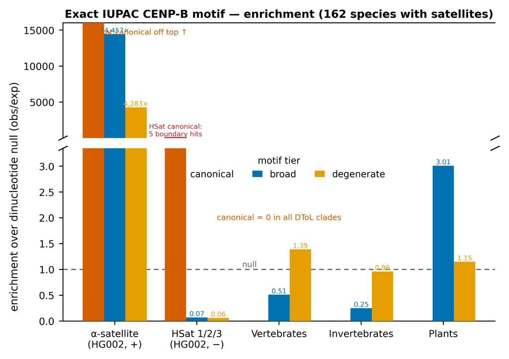

**(i) Enrichment** over the dinucleotide null (obs/exp), per clade × tier (broken y-axis; α-satellite ≫ DToL). Canonical = 0 in all DToL clades; HSat canonical = 5 boundary hits (hatched).

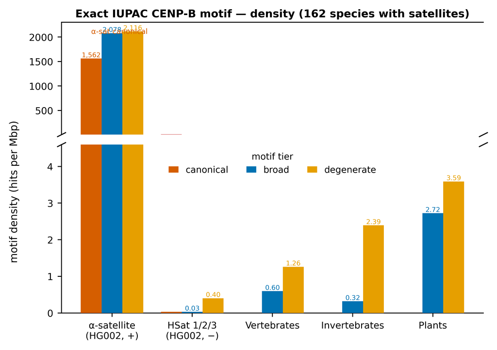

**(ii) Motif density** — exact IUPAC hits per Mbp, per clade × tier (broken y-axis).

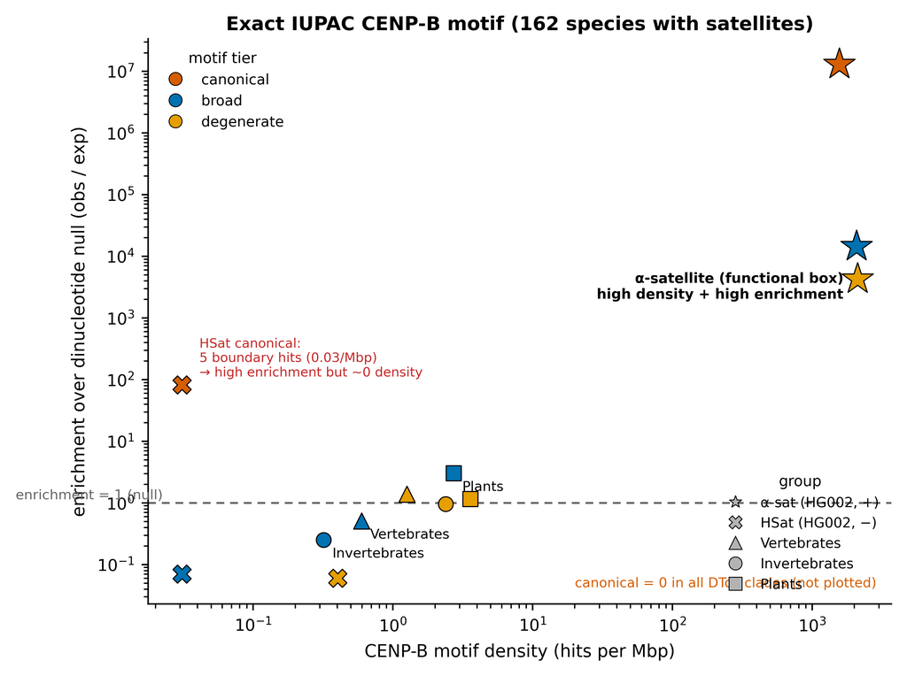

**(iii) Scatter** of enrichment (i) vs density (ii). A real box needs **both**: only **α-satellite** sits top-right. HSat canonical is a lone point at ~0.03/Mbp (5 boundary hits → high enrichment but ~0 density — not a box). DToL clades sit near the null (enrichment ≈ 1).

| clade | n_species | canonical | broad | degenerate |
| --- | --- | --- | --- | --- |
| Vertebrates | 23 | 0.0 | 0.51 | 1.39 |
| Invertebrates | 91 | 0.0 | 0.25 | 0.96 |
| Plants | 48 | 0.0 | 3.01 | 1.15 |

**Note.** This uses composition-corrected *enrichment*, not raw hits/Mbp — raw density inflates plants (AT-rich, more satellite bp). Under the dinucleotide null the looser-tier enrichments are modest (plants lead the broad tier, 3.0×; vertebrates the degenerate tier, 1.4×) and the apparent plant broad signal deflates (11.7× → 3.0×).

## Method 2 — songbird ±5-flank test (Formenti et al., Cell 2026)

This is a permissive, distance-based search (following the zebra-finch T2T paper, Formenti et al. 2026, Suppl. Fig. 15). It runs per species on the uncapped satellite arrays, in six steps:

1. **Find windows.** Slide along every satellite array, on **both strands**, and record every 17-bp stretch that matches the canonical box `[CT]TTCGTTGGAA[AG]CGGGA` within **≤5 substitutions** (fuzzy matching). Each such 17-bp hit is a **window**. We record `n_windows` (total per species) and **prevalence** = windows per Mbp of satellite.
2. **Add flanks.** Extend each window by 5 bp on each side → a **27-bp window** (5 + 17 + 5). The flanks are a built-in negative control.
3. **Stack into a position matrix.** Pile all of a species' 27-bp windows and count, at each column, how often each base (A/C/G/T) occurs — a position frequency matrix.
4. **Information content (conservation).** Per column, IC = 2 + Σ<sub>b</sub> p<sub>b</sub> log₂ p<sub>b</sub> bits (0 = random, 2 = one fixed base). Then **motif information** = mean IC over the 17 motif columns, **flank information** = mean IC over the 10 flank columns, and **Δ = motif − flank**. A real motif is **conserved within itself but random in the flanks** → high motif information, low flank information → Δ > 0 (the scatter's y and x axes).
5. **Consensus & identity.** The **consensus** = the most common base per motif column (used for the scatter colour and the reported substitutions-from-canonical). For the null test we score identity **per window** — the mean, over all of a species' 17-bp windows, of (positions matching the canonical IUPAC)/17 × 100%. Doing this per window (rather than on the consensus) avoids the **degenerate-consensus artifact**: a high-copy satellite whose windows deviate at *random* positions has a canonical-looking consensus (≈100%), yet its individual windows sit at the ≤5-substitution floor (~70%).
6. **Shuffle-the-window null.** Each window's bases are shuffled (composition preserved, order destroyed) and identity re-scored → the chance level (≈29%). Observed per-window identity (~70–81%) sits far above chance (windows are compositionally box-like), though near the floor.

**Definitions.** *window* = one located 17-bp box-like hit; *consensus* = the per-position majority base over a species' windows; *Δ* = motif − flank information; *prevalence* = windows/Mbp. **Note:** per-window identity is ~70% for every species (the ≤5-substitution floor), so it does not single out particular species. The species-specific box-likeness (e.g. the goshawk's 15/17 consensus) is a **consensus/coherence** property — its windows deviate *consistently* (the eroded CpG) so the average keeps that off-canonical signature — and is best seen in the logos and the alignment below, together with the flank Δ.

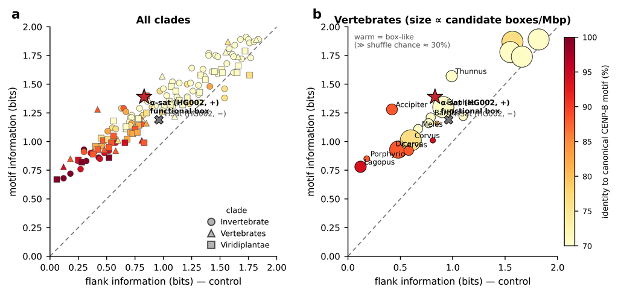

Box vs flank information, coloured by **identity to the canonical CENP-B motif**. A **candidate box** = high identity *and* above the motif=flank diagonal (motif-specific). α-satellite (red star) = the functional box; HSat (grey ×) = negative. Birds (goshawk, takahē, ptarmigan) are the most box-specific vertebrates; falcons sit on the diagonal (conserved satellite, not a candidate box).

### Top vertebrates by flank Δ (box − flank)

| species | group | n_windows | boxes/Mbp | box bits | flank bits | Δ | consensus | subs |
| --- | --- | --- | --- | --- | --- | --- | --- | --- |
| Accipiter gentilis | Aves | 1722 | 88.35 | 1.28 | 0.42 | 0.85 | CTTTTTTGGAAACGGGA | 2.0 |
| Porphyrio hochstetteri | Aves | 345 | 25.61 | 0.85 | 0.18 | 0.68 | TTTCCTTGGAAACGGAA | 2.0 |
| Lagopus muta | Aves | 189 | 95.20 | 0.78 | 0.12 | 0.66 | CTTTGTTGGAAACGGGA | 1.0 |
| Thunnus maccoyii | Fish | 30 | 92.02 | 1.57 | 0.99 | 0.58 | TTTCATCAGAATCGAGA | 5.0 |
| Diceros bicornis | Mammalia | 566 | 7.42 | 0.94 | 0.42 | 0.52 | CTTCCTTAGAAGCAGGA | 3.0 |
| Cervus elaphus | Mammalia | 38716 | 217.25 | 0.93 | 0.48 | 0.45 | TTTCGTGGGAAGGGGGA | 2.0 |
| Meles meles | Mammalia | 725 | 58.10 | 1.11 | 0.67 | 0.45 | TTTGGTAGCATAAGGGA | 5.0 |
| Barbus barbus | Fish | 594 | 61.81 | 1.21 | 0.79 | 0.42 | CTTCTTTCGCAGTGAGA | 5.0 |

Box-like motifs (Δ≥0.5, ≤2 substitutions from canonical) occur in **20 species across clades**, strongest in birds; the scatter is coloured by identity to the canonical motif (warm = box-like).

### How many species "recover" a box-like motif?

Of the 162 species with satellites, **152 (94%)** contain at least one ≤5-substitution box-like window; 6 have only 1–4 weak hits; and **4 recover nothing** (*Bibio marci*, *Limnoperna fortunei*, *Pholis gunnellus*, *Lemur catta* — AT-rich satellites lacking the GC-rich `TTCG…CGGG` core). But **≤5 substitutions on 17 bp is very permissive** — nearly any GC-containing satellite has such a window by chance — so 94% recovery is *expected*, not evidence of real boxes. This is precisely why the unbiased test below is needed.

**Why ≤5 subs matches so easily.** If a satellite had *no* real box, how many of its 17-mers would still fall within ≤5 substitutions of the box by chance? This expected number is **E = D × p**, where **p** = the probability that one random 17-mer is ≤5 substitutions from the box, and **D** = the number of **distinct** 17-mers the satellite contains.

**The per-motif probability, p — computed exactly.** The box fixes a specific base at 15 of the 17 positions (2 positions allow 2 bases). A random base matches a fixed position only **¼** of the time and a degenerate position **½**, so a random 17-mer is *expected* to have 15×¾ + 2×½ = **12.25 mismatches** — i.e. it matches the box at only ~5 of 17 positions by chance. A ≤5-substitution match needs ≥12 matches — deep in the tail, hence rare. Counting exactly: each fixed position contributes (1 match + 3 mismatch) bases and each degenerate (2 + 2), so the number of 17-mers with exactly *k* mismatches is the coefficient of *x<sup>k</sup>* in **(1+3x)<sup>15</sup>(2+2x)<sup>2</sup>**. Summing *k* = 0…5 and dividing by 4<sup>17</sup> (≈ 17 billion): ~4.4 million qualify, so **p ≈ 2.6×10⁻⁴ ≈ 1 in 3,850**.

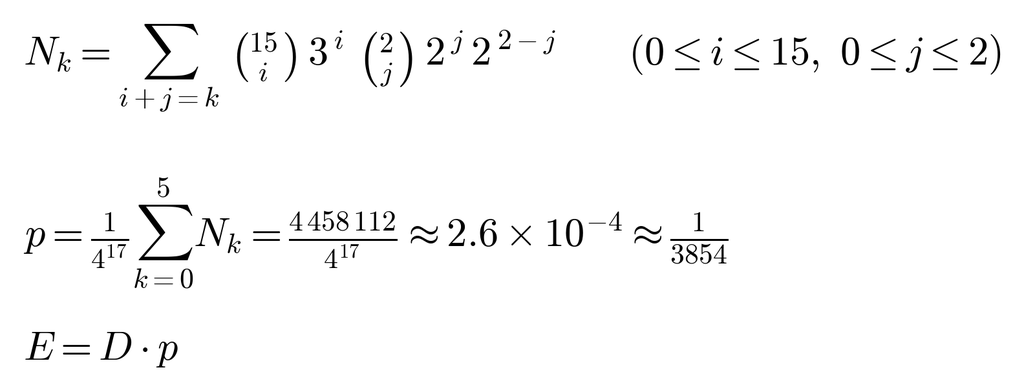

Formal definition. *N<sub>k</sub>* = number of 17-mers at exactly *k* mismatches, split as *i* on the 15 fixed positions and *j* on the 2 degenerate positions: the fixed factor `C(15,i)·3ⁱ` picks which fixed positions mismatch (3 wrong bases each), the degenerate factor `C(2,j)·2ʲ·2²⁻ʲ` likewise. *p* sums *k* = 0…5 over all 4¹⁷ possible 17-mers; *D* = number of distinct 17-mers in the satellite; *E* = *D·p* = expected chance matches.

| threshold | fraction of all 4¹⁷ 17-mers (exact) | ≈ 1 in |
| --- | --- | --- |
| ≤2 substitutions | 2.5×10⁻⁷ | **4,000,000** |
| ≤3 substitutions | 3.6×10⁻⁶ | 281,000 |
| ≤4 substitutions | 3.5×10⁻⁵ | 28,000 |
| **≤5 substitutions** | **2.6×10⁻⁴** | **~3,850** |

**The count, D — the key correction.** D is the number of **distinct** 17-mers, **not** the total number of windows. A satellite is a tandem repeat, so the same 17-mers recur thousands of times; repeated copies of an already-counted k-mer are not independent opportunities to match, so only the distinct k-mers contribute. Measured (both strands):

| species | total windows | distinct 17-mers (D) | E = D × p |
| --- | --- | --- | --- |
| goshawk (very homogeneous) | 631,000 | ~5,000 (0.8% unique) | **~1.3** |
| Danio (fish) | 677,000 | ~11,000 | ~2.9 |
| Nebria (invertebrate) | 487,000 | ~37,000 | ~9.5 |
| Triglochin (diverse plant) | 4,300,000 | ~284,000 (6.6% unique) | ~74 |

**The CENP-B box is functional, not abundant.** Tellingly, the box is *not* the most common sequence even in human α-satellite: the most frequent 17-mer there is `CAAAAAGAGTGTTTCA` (~18% identity to the box) — a different conserved part of the 171-bp monomer. The box is a specific, functionally conserved ~17 bp region, so it must be searched for *as the box*; a de-novo "dominant motif" scan would miss it entirely. That is why the test below scans for the best *box-matching* window at any position, rather than the satellite's single most abundant motif.

### Unbiased de-novo test (no CENP-B seeding) — the decisive check

The ±5-flank search is **seeded** on the CENP-B box, so it only ever collects windows that are already ≤5 substitutions from it — it cannot tell whether a satellite's *own* motif is box-like (indeed ~99% of the windows it finds sit at exactly 5 substitutions, the matching boundary). To remove this bias we scan **every** 17-bp window of every array (both strands, no seeding), take the single **best** match to the canonical box, and compare to the same on a **dinucleotide shuffle** of the array (which controls for the "best of many windows" inflation). A satellite that genuinely carries a box in its repeat unit — like α-satellite — scores well above its shuffle; an unrelated satellite scores on the null.

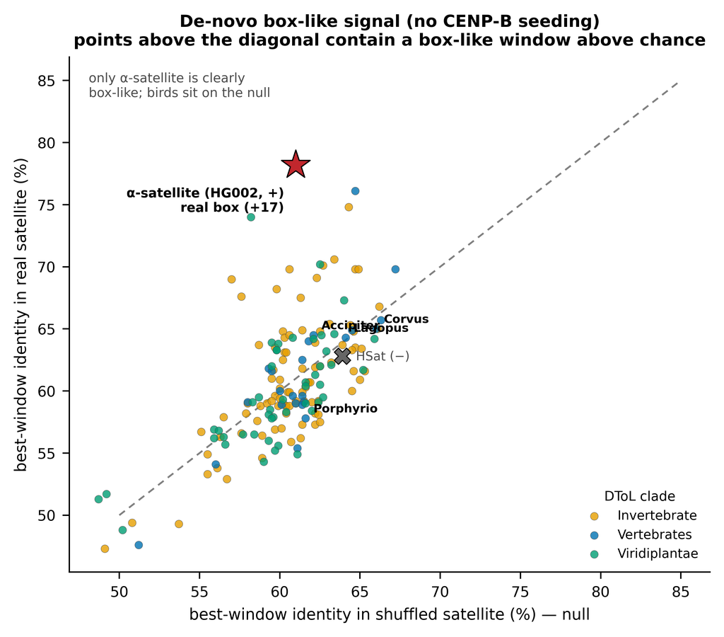

Best-window identity in the real satellite (y) vs a dinucleotide shuffle (x). Note the **null is already high (~61%)** — scanning ~300 windows of *any* sequence finds a decent match to a 17-bp motif — so absolute values are close and the **excess** (distance above the diagonal) is the signal. **α-satellite** (red star) is clearly above (78% vs 61%, **+17**) — a real box in every monomer. **HSat** (−1) is on the null. DToL clades — including the **birds** (goshawk +2.4, ptarmigan +0.2, takahē −3.8) — sit near the diagonal (median excess −0.8; 5/162 clear +10, all well below α-sat). `cenpb_denovo_bestwindow.py`

**Reading the two methods together.** Both are reported because they answer different questions. The **seeded ±5-flank** search highlights a genuine, interesting observation: several birds carry a satellite consensus that is **15/17 identical to the CENP-B box** (goshawk `CTTTTTTGGAAACGGGA`, missing only the CpG). The **unbiased de-novo** test then asks whether that resemblance exceeds chance *per array* — and it does not (the birds sit on the null; the 15/17 consensus arises because the box-matched windows are pre-selected and their random deviations average out). So the honest reading: birds have a **candidate CENP-B-like motif worth following up** (near-canonical consensus, box-shaped by flank Δ, TIGD-family binder plausible), but it is **not confirmed** as a box-carrying satellite the way human α-satellite is.

### Why the two methods disagree on birds

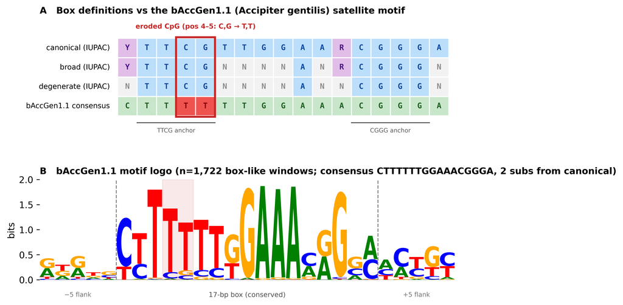

**(A)** the box definitions (canonical/broad/degenerate IUPAC) aligned to the goshawk satellite consensus, and **(B)** the goshawk motif itself as a sequence logo (its 1,722 box-like windows + ±5 flanks): a conserved 17-bp box with random flanks, with the eroded CpG visible.  
The goshawk motif is 15/17 identical to canonical; its only two substitutions land on the 5′ **CpG** (positions 4–5) that *all three* IUPAC tiers hold fixed (the TTCG anchor). So position-based IUPAC matching scores **0**, while the distance-based songbird ≤5-substitution search (no fixed position) finds 1,722 windows. The eroded position is a CpG — a CENP-B contact base and a methylation/deamination hotspot — which is exactly why it is a **candidate divergent box**, not a canonical one.

## CENP-B box across the chronogram

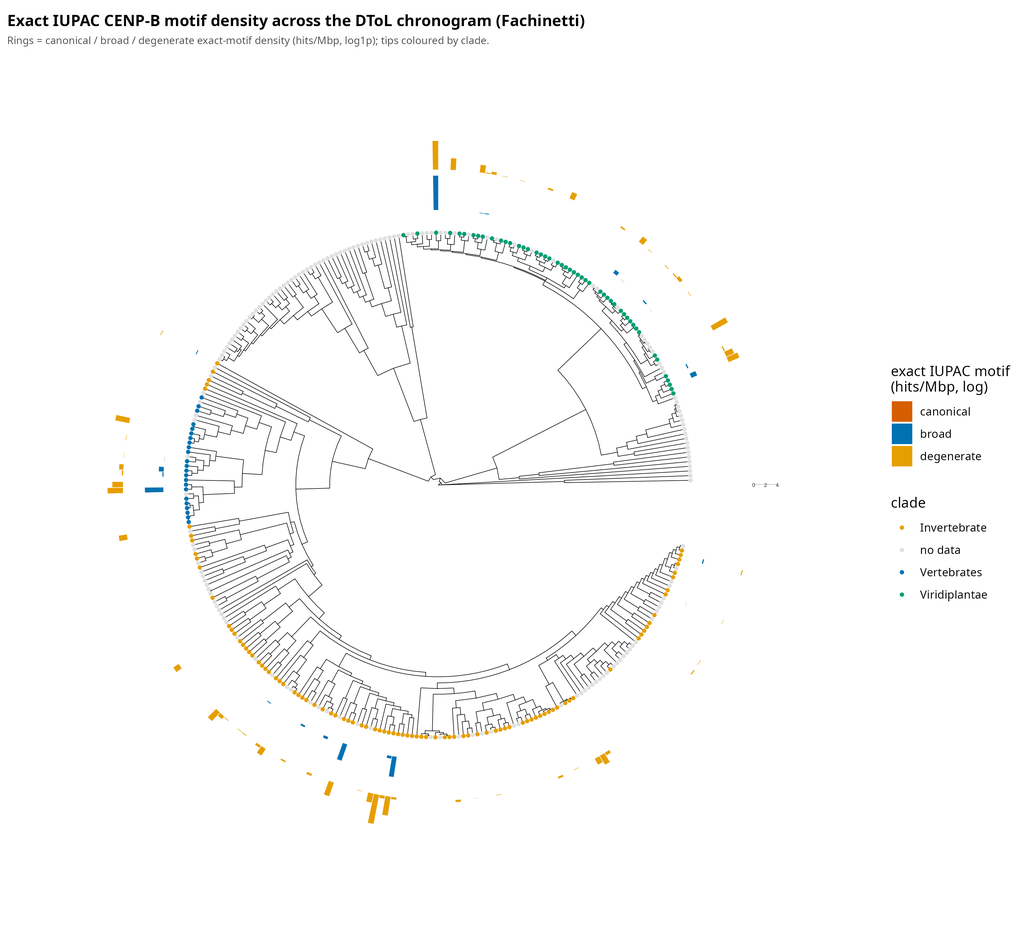

Per-species logos (box ±5 flank), including the human α-sat and HSat controls: `figures/cenpb_box_logos_flanks_VERTEBRATES_uncapped.pdf`.